# Introduction to R and RStudio Day 2 JCSMR Workshop for Students https://github.com/numicator/ANU_R_workshop

### Scatter plots

To create an X-Y or a scatter plot, we use the geometry `geom_point`.  
To ensure that the plot will appear in any situation we **should** explicitly print it with the `print()` function rather than rely on R ability to correctly direct the output.

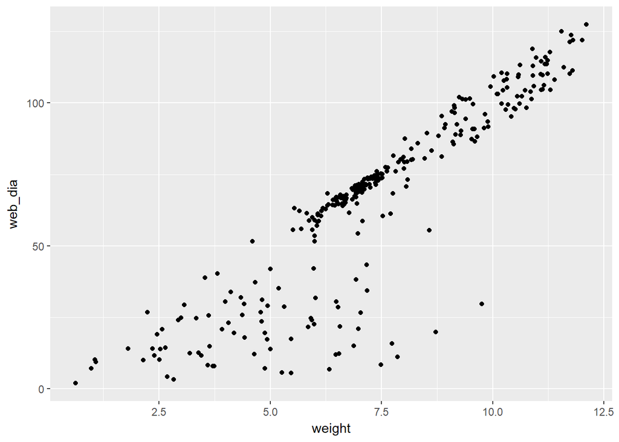

```r
print(g + geom_point())
```

> In the following examples we will ommit the `print()` function for simplicity.

On the plot above we got all the data point from all three populations plotted in the same color. What if we wanted to see the populations color-separated?  
To achieve this we will use the the ‘group by colour’ functionality by adding argument `colour` (or `color`) to the `aes` function: `colour = population`. Assigning `population` to the `colour` argument tells ggplot to color the plot’s points with color depending on the value of the `population` column.  
We can either add the `colour` to the `aes` already passed to the `ggplot` or add a new `aes` with only the `colour = population` argument to the `geom_point` function.  
Do you know what is the difference between adding `colour = population` to the `aes` in `ggplot` vs. in `geom_point`?

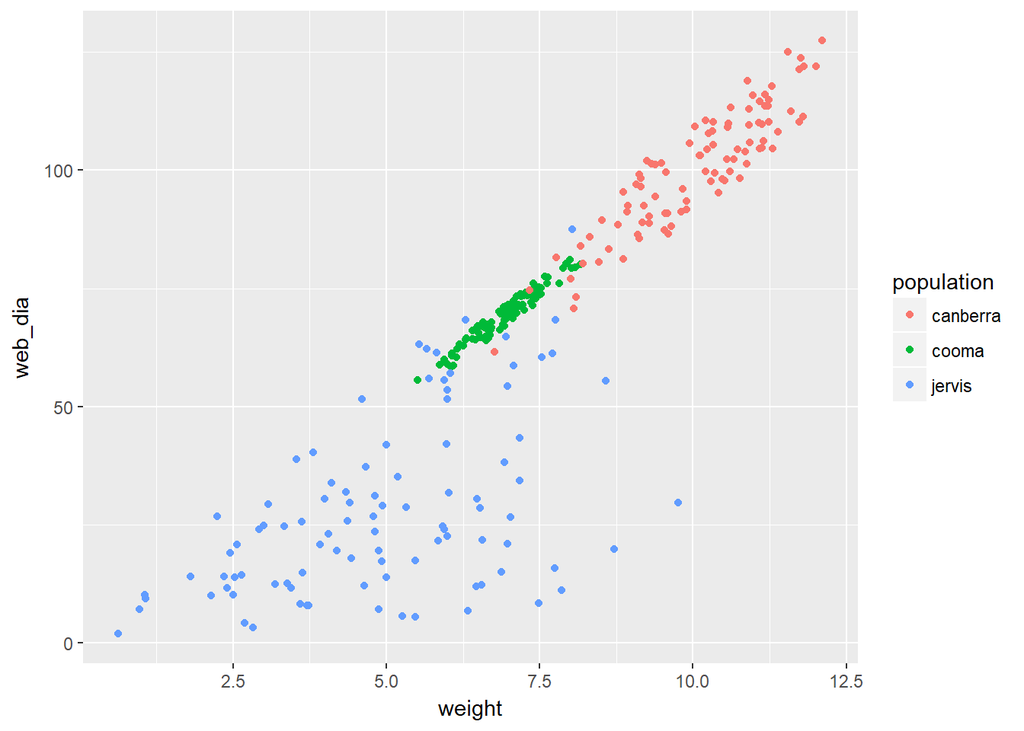

```r
g + geom_point(aes(colour = population))
```

Now lets fit a linear model (a line) to the data points with the `geom_smooth(method = 'lm')` function. The `lm` is the ‘linear model’.

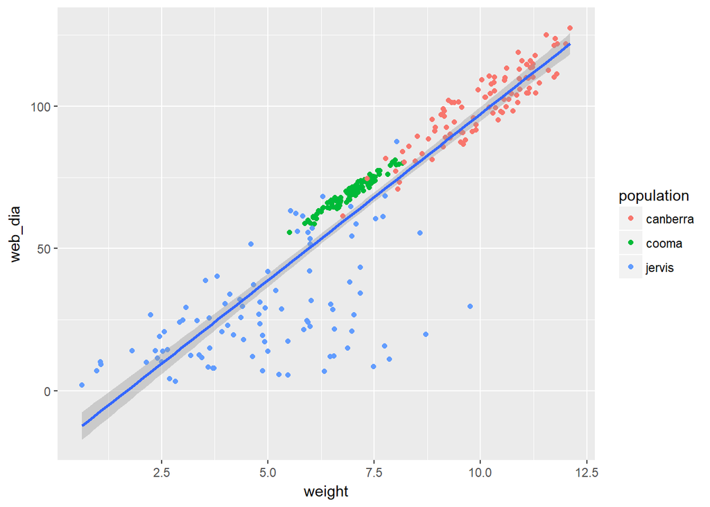

```r
g + geom_point(aes(colour = population)) + geom_smooth(method = 'lm')
```

Please refer to the R manual to learn how to fit other functions to the data, e.g. Local Polynomial Regression `loess`.

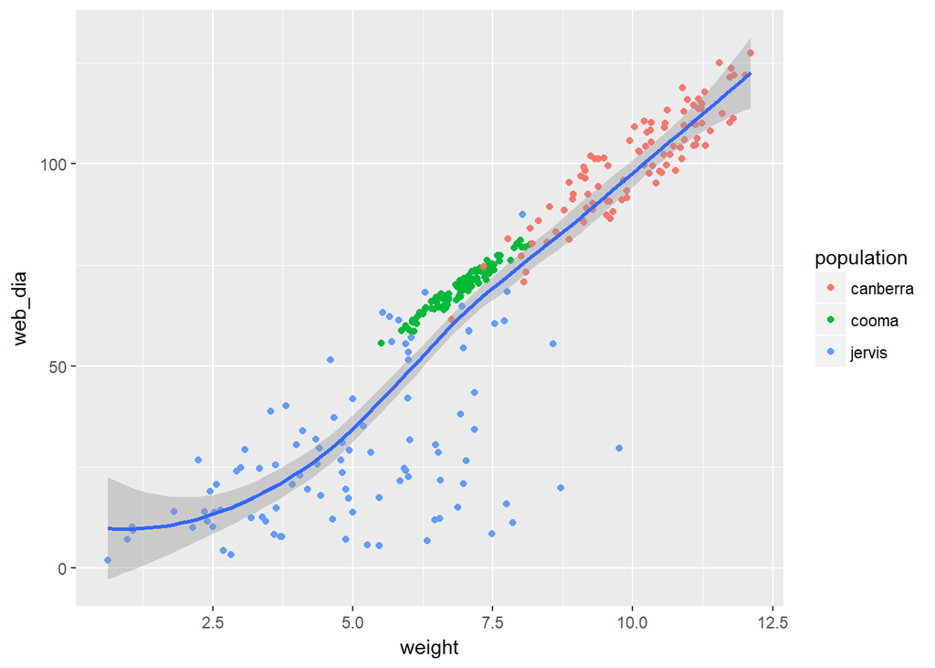

```r
g + geom_point(aes(colour = population)) + geom_smooth(method = 'loess')
```

We can fit the line to the data points separately for each population:

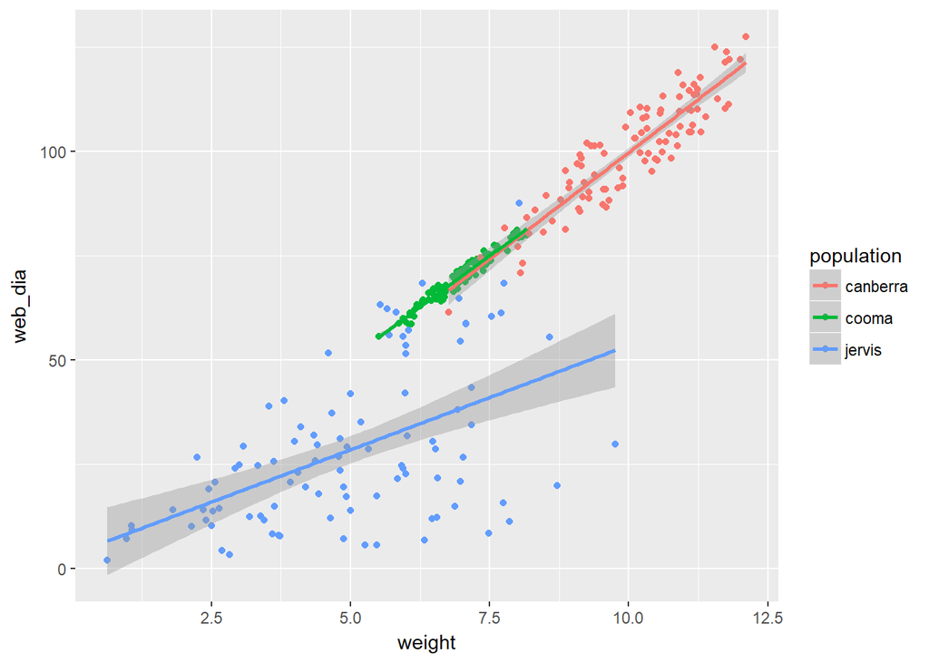

```r
g + geom_point(aes(colour = population)) + geom_smooth(method = 'lm', aes(colour = population))
```

For a better visibility we can create a separate *facet* for each population adding a new *layer* with the `facet_wrap(~ population)` function:

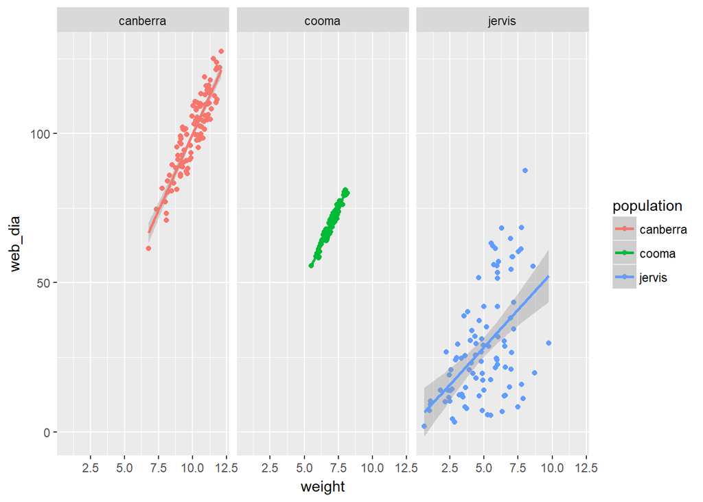

```r
g + geom_point(aes(colour = population)) + geom_smooth(method = 'lm', aes(colour = population)) + facet_wrap(~ population)
```

### Box plots

A box plot is a standardized way of displaying the distribution of data.

From the http://ggplot2.tidyverse.org/reference/geom_boxplot.html manual:  
‘The lower and upper hinges correspond to the first and third quartiles (the 25th and 75th percentiles). The upper whisker extends from the hinge to the largest value no further than 1.5 * IQR from the hinge (where IQR is the inter-quartile range, or distance between the first and third quartiles). The lower whisker extends from the hinge to the smallest value at most 1.5 * IQR of the hinge. Data beyond the end of the whiskers are called “outlying” points and are plotted individually.’

A box plot showing the web diameter in different spider populations may look like this:

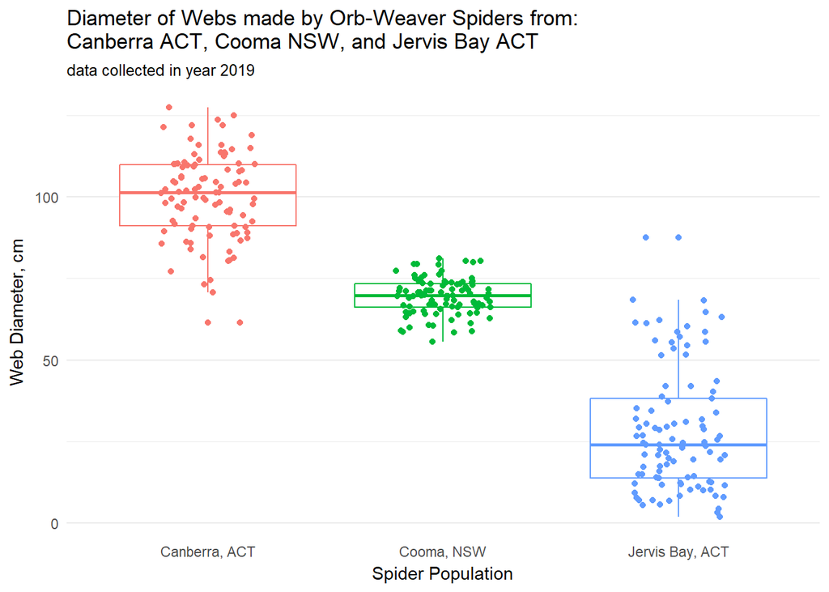

```r
ggplot(
  data = spider, mapping = aes(x = population, y = web_dia, colour = population)) +
    geom_boxplot() +
    geom_jitter(width = 0.2) +
    xlab("Spider Population") +
    ylab("Web Diameter, cm") +
    scale_x_discrete(breaks = c("canberra", "cooma", "jervis"), labels = c("Canberra, ACT", "Cooma, NSW", "Jervis Bay, ACT")) +
    ggtitle("Diameter of Webs made by Orb-Weaver Spiders from:\nCanberra ACT, Cooma NSW, and Jervis Bay ACT", subtitle = "data collected in year 2019") +
    theme_minimal() +
    theme(legend.position="none", panel.grid.major.x = element_blank())
```

The code looks a bit intimidatingâ¦ We will create this graph in steps: Start from creation of the ggplot object.

- What is the data?

And the `aes` function inside of the `ggplot`

- What is on x axis?
- What is on y axis?
- What is the grouping factor (the colour)?

```r
g <- ggplot(data = spider, mapping = aes(x = population, y = web_dia, colour = population))
```

Now, having the canvas ready we can add the box plot geometry.

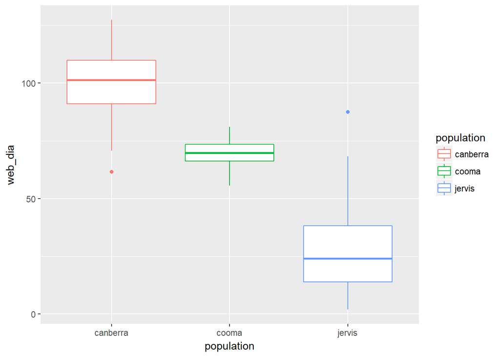

```r
g + geom_boxplot()
```

As you can see we are still missing a few element, called layers on the plot:

- The data points can be added with `geom_point` or as in this case with `geom_jitter`.
- The x and y axes labels with `xlab` and `xlab`.
- The title with `ggtitle`.

Advanced options:

- The x-axis tick labels were added with `scale_x_discrete`.
- The over-all look of the graph was changed with `theme_minimal()`.
- The legend was hidden with `theme(legend.position="none")`.

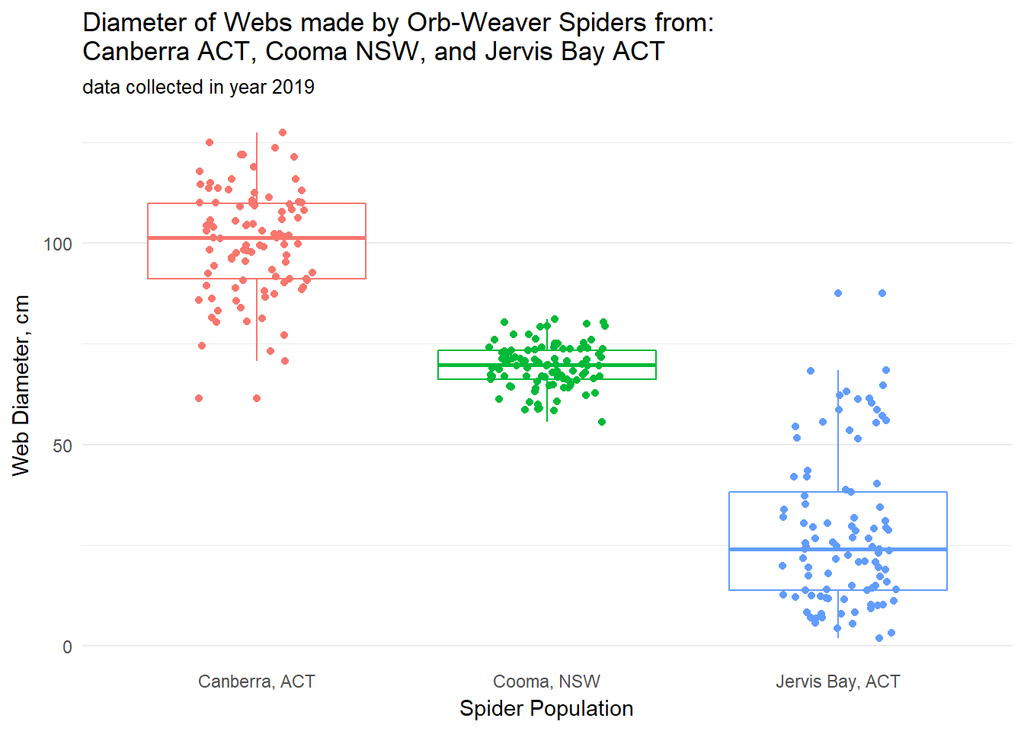

```r
print(ggplot(
  data = spider, mapping = aes(x = population, y = web_dia, colour = population)) +
    geom_boxplot() +
    geom_jitter(width = 0.2) +
    xlab("Spider Population") +
    ylab("Web Diameter, cm") +
    scale_x_discrete(breaks = c("canberra", "cooma", "jervis"), labels = c("Canberra, ACT", "Cooma, NSW", "Jervis Bay, ACT")) +
    ggtitle("Diameter of Webs made by Orb-Weaver Spiders from:\nCanberra ACT, Cooma NSW, and Jervis Bay ACT", subtitle = "data collected in year 2019") +
    theme_minimal() +
    theme(legend.position="none", panel.grid.major.x = element_blank())
  )
```

### Violin Plots:

Convert the box-plot into a violin plot. Hint: It can’t be simpler: Check `geom_boxplot` vs. `geom_violin`.

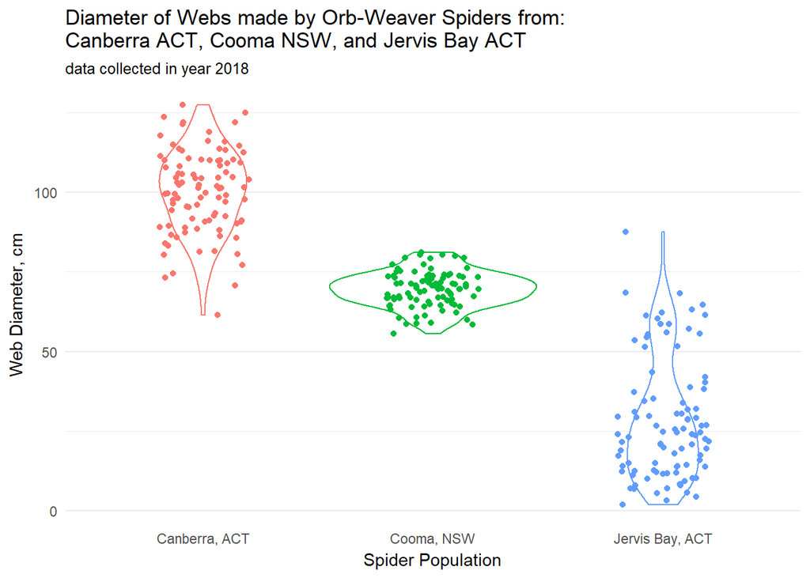

```r
print(ggplot(
  data = spider, mapping = aes(x = population, y = web_dia, colour = population)) +
    geom_violin() +
    geom_jitter(width = 0.2) +
    xlab("Spider Population") +
    ylab("Web Diameter, cm") +
    scale_x_discrete(breaks = c("canberra", "cooma", "jervis"), labels = c("Canberra, ACT", "Cooma, NSW", "Jervis Bay, ACT")) +
    ggtitle("Diameter of Webs made by Orb-Weaver Spiders from:\nCanberra ACT, Cooma NSW, and Jervis Bay ACT", subtitle = "data collected in year 2018") +
    theme_minimal() +
    theme(legend.position="none", panel.grid.major.x = element_blank())
  )
```

You can tune up the violins by e.g. filling them up with the colour of the population by adding aes object with argument `fill = population`. You can also add the argument `alpha = 0.75` to make the fill slightly translucent to better show the data points.

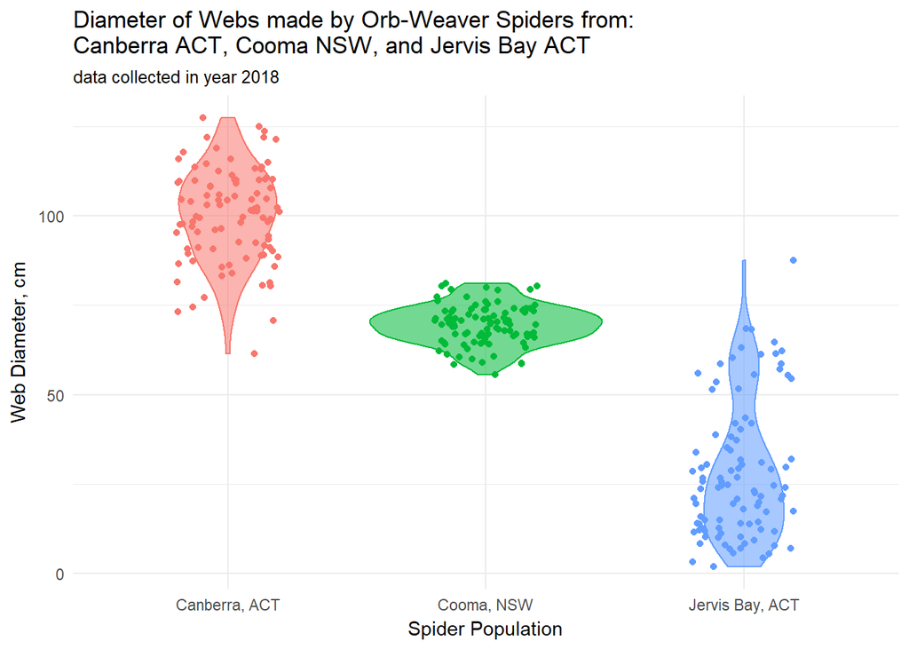

```r
print(ggplot(
  data = spider, mapping = aes(x = population, y = web_dia, colour = population)) +
    geom_violin(aes(fill = population, alpha = 0.75)) +
    geom_jitter(width = 0.2) +
    xlab("Spider Population") +
    ylab("Web Diameter, cm") +
    scale_x_discrete(breaks = c("canberra", "cooma", "jervis"), labels = c("Canberra, ACT", "Cooma, NSW", "Jervis Bay, ACT")) +
    ggtitle("Diameter of Webs made by Orb-Weaver Spiders from:\nCanberra ACT, Cooma NSW, and Jervis Bay ACT", subtitle = "data collected in year 2018") +
    theme_minimal() +
    theme(legend.position="none")
  )
```

### Histograms:

Histogram - a representation of the distribution of numerical data. Histogram groups the numbers into ranges, or *bins* and presents counts (or frequencies) of the observations within the bins.

So, let’s create a historgam represengting distribution of spider weights. Use `geom_histogram`. What should be assigned to *x* axis? Don’e assign anything to *y* axis.

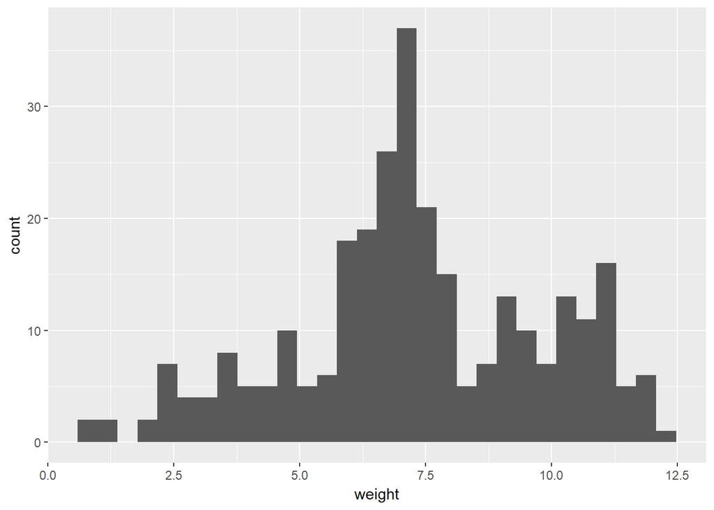

```r
print(ggplot(data = spider, mapping = aes(x = weight)) +  geom_histogram())
```

We can decide on number of *bins* with argument `bins` passed to `geom_histogram`

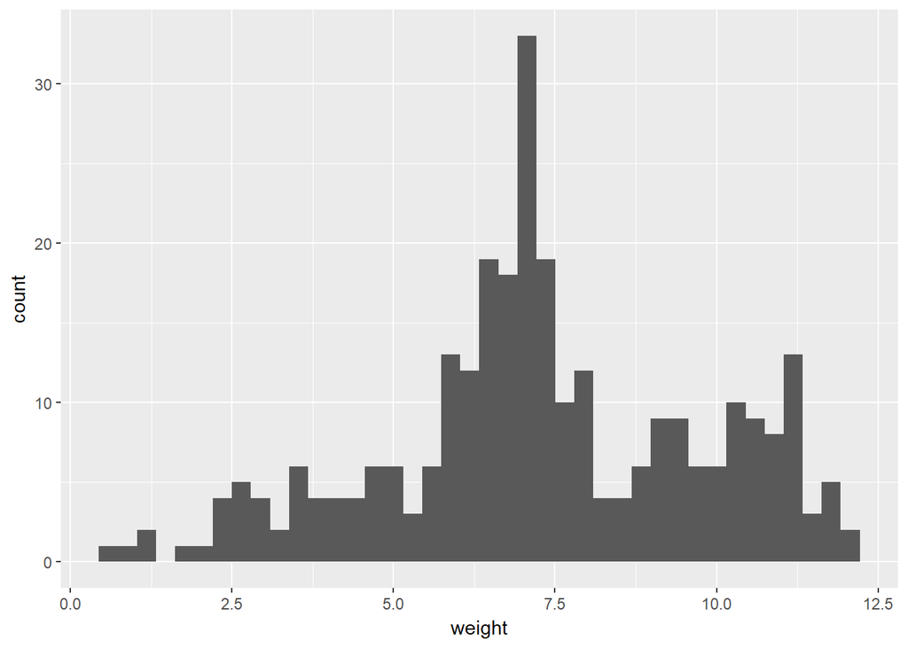

```r
print(ggplot(data = spider, mapping = aes(x = weight)) +  geom_histogram(bins = 40))
```

We can present the data grouped by colour. To get both the outline and fill of the bars colored we need to use arguments `color` and `fill` and set them to `population`:

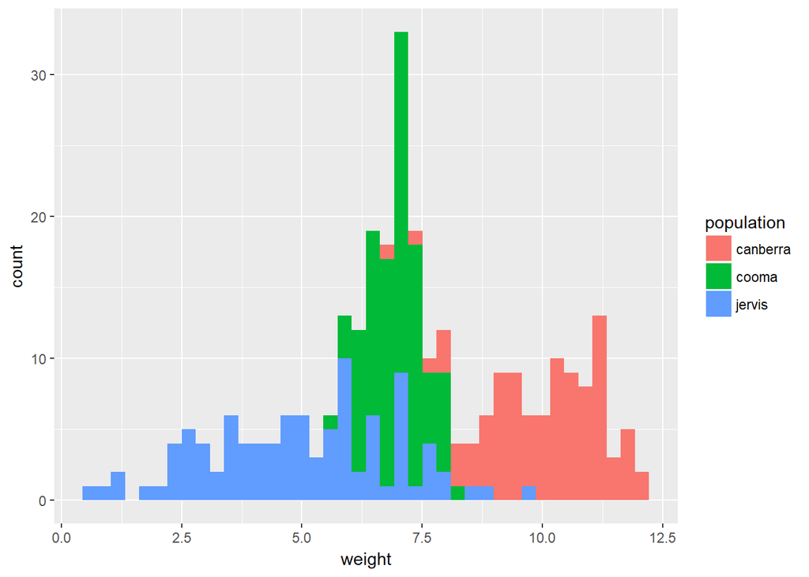

```r
print(ggplot(data = spider, mapping = aes(x = weight, cloor = population, fill = population)) +  geom_histogram(bins = 40))
```

We can generate a similar histogram showing distribution of diameters of the webs:

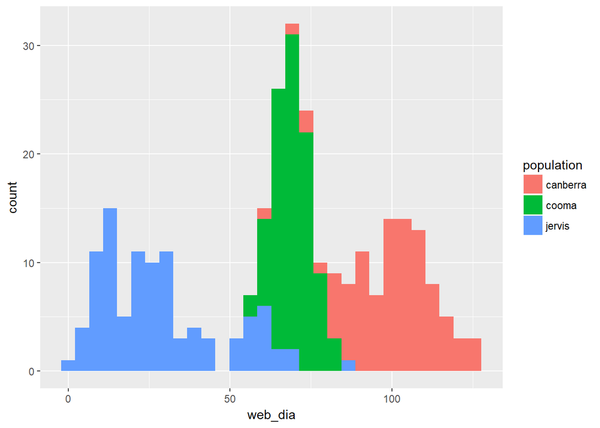

```r
print(ggplot(data = spider, mapping = aes(x = web_dia, cloor = population, fill = population)) +  geom_histogram(bins = 30))
```

# Working with Data: Chromosomal Sex

Our second example today: Data from genetic variation project in human population. Genetic material collected from 200 patients to analyse genetic variation within the population. 64 samples (from the 200) were randomly selected and sequenced. The sequence reads were mapped to human reference genome.  
Unfortunately the data on sex of the patients was lost. We will attempt to recover missing sex information by analysing number reads mapped to Y chromosome. We use the fact that male subjects have the Y chromosome, where the female don’t. It means that our data should show coverage on Y chromosome only for male subjects.

Our task is to:

1. Read the data into R.
2. Plot count_y vs. count_all
3. Add calculated column ratio = count_y / count_all.
4. Make a histogram to see distribution of the ratios.
5. Choose a cutoff value to separate males from females
6. Add column sex: ‘M’ if ratio greater than the cutoff, ‘F’ if ratio lesser than the cutoff.
7. Make a box-plot with the two categories - ‘M’ and ‘F’

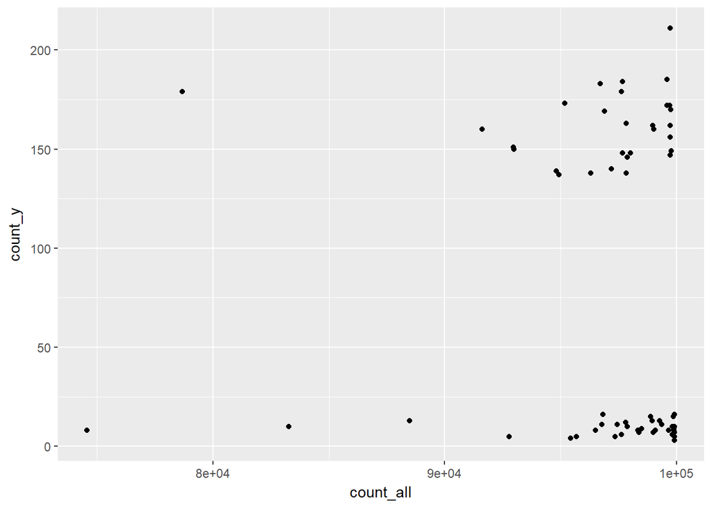

```r
chr_mapcount <- read.table("chr_mapcount.tsv", sep = "\t", header = TRUE, stringsAsFactors = FALSE)

ggplot(data = chr_mapcount, mapping = aes(x = count_all, y = count_y)) +
  geom_point()
```

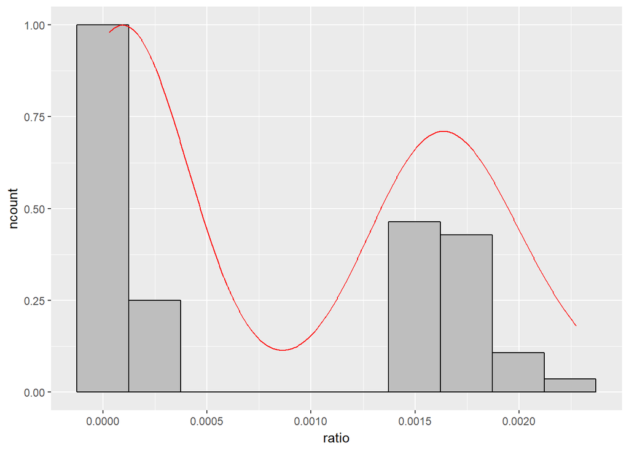

```r
chr_mapcount$ratio <- chr_mapcount$count_y / chr_mapcount$count_all

ggplot(data = chr_mapcount, mapping = aes(x = ratio)) +
  geom_histogram(aes(y = ..ncount..), bins = 10, fill = "grey", color = "black") +
  stat_density(aes(y = ..scaled..), color = "red", geom = "line")
```

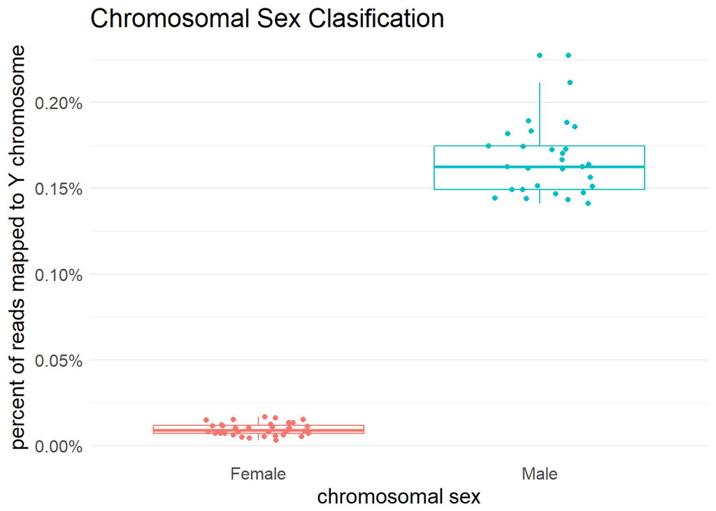

```r
chr_mapcount$sex <- ''
chr_mapcount[chr_mapcount$ratio >= .0008, "sex"] <- "M"
chr_mapcount[chr_mapcount$ratio <  .0008, "sex"] <- "F"

ggplot(data = chr_mapcount, mapping = aes(x = sex, y = ratio, colour = sex)) +
  geom_boxplot() +
  geom_jitter(width = 0.2) +
  scale_y_continuous(labels = scales::percent) +
  scale_x_discrete(breaks = c("F", "M"), labels = c("Female", "Male")) +
  xlab("chromosomal sex") +
  ylab("percent of reads mapped to Y chromosome") +
  ggtitle("Chromosomal Sex Clasification") +
  theme_minimal() +
  theme(legend.position = "none", panel.grid.major.x = element_blank(), text = element_text(size = 15))
```

# Reshaping data from *wide* to *long* format and re-ordering factors: The Barley Yeld Example

We often need to convert our data from the *wide* to the *long* format. The *wide* format is where:

- each column is a variable
- each row is an observation

In the *long* format, you usually have 1 column for the observed variable and the other columns are ID variables.

In the *wide* format each row is often a site/subject/patient and you have multiple observation variables containing the same type of data. These can be either repeated observations over time, or observation of multiple variables (or a mix of both). You may find data input may be simpler or some other applications may prefer the *wide* format. However, many of R functions have been designed assuming you have *long* format data.

```r
download.file("http://leucon.anu.edu.au/marcin/r_data/barley_wd", "barley_wd.csv")
barley.wd <- read.table("barley_wd.csv", sep = ",", header = TRUE)
```

Data in wide format:

| Location | Variety | Year1 | Year2 |
| --- | --- | --- | --- |
| UF | M | 81.0 | 80.7 |
| UF | S | 105.4 | 82.3 |
| UF | V | 119.7 | 80.4 |
| UF | T | 109.7 | 87.2 |
| UF | P | 98.3 | 84.2 |

Data in long format:

| Location | Variety | Year | Yield |
| --- | --- | --- | --- |
| UF | M | Year1 | 81.0 |
| UF | S | Year1 | 105.4 |
| UF | V | Year1 | 119.7 |

To *reshape* from *wide* to *long* we will use function `gather` from `tidyr` package.

> We may need to install `tidyr` first!

```r
library(tidyr)
barley.long <- gather(barley.wd, key = Year, value = Yield, Year1, Year2)
```

BTW, to do the opposite - convert from long to wide we can use function `spread`

```r
barley.wd2 <-  spread(barley.long, key = Year, value = Yield)
```

Another common task is to change order of the levels of a factor  
E.g. column `Location` is a factor with levels:

```r
class(barley.long$Location)
```

```
## [1] "factor"
```

```r
levels(barley.long$Location)
```

```
## [1] "C"  "D"  "GR" "M"  "UF" "W"
```

Often statistical analyses require certain order of the factor levels. E.g. the control to be first. Let’s assume that in our case level “W” is the control and we want it to be first.  
To reorder levels of a factor we simply create a new factor using the existing as source of the data and specify the order of levels with argument `levels`:

```r
barley.long$Location <- factor(barley.long$Location, levels = c("W", "C", "D", "GR", "M", "UF"))
```

slides 77-79

# Data Wrangling with apply function

## Example

First lets have a look at a simple examle (taken from https://www.r-bloggers.com/the-r-apply-function-a-tutorial-with-examples/ ):  
Given a matrix

```r
m <- matrix(c(seq(from = 1, to = 100, by = 1)), nrow = 10, ncol = 10)
View(m)
```

### Tasks:

1. return the sum of all values in each rows

```r
apply(m, 1, sum)
```

```
##  [1] 460 470 480 490 500 510 520 530 540 550
```

2. return the sum of of all values in each columns

```r
apply(m, 2, sum)
```

```
##  [1]  55 155 255 355 455 555 655 755 855 955
```

3. return a new matrix whose entries are those of ‘m’ plus 10

```r
m2 <- apply(m, c(1,2), function(x) x + 10)
View(m2)
```

## Excercise

Now, we are ready to work of our scenario:  
Our coleague asks as for help. She has a multicolumn numerical dataset. For her statistical analysis she needs that dataset to have only the rows in which there are at least two non-zero values.  
Additionally we should replace all those “DV12” stings in the first column with “NEW12”.

```r
rm(list = ls())
download.file("http://leucon.anu.edu.au/marcin/r_data/tcr.csv", "tcr.csv")
tcr <- read.table("tcr.csv", sep = ",", header = TRUE, stringsAsFactors = FALSE)
```

> TIP: Add a new column with the number of non-zero values.

> We need to somehow ommit the column with identifiers.

Add the extra column with number of non-zero values in each row:

```r
tcr$non.zero <- apply(tcr[, 2:ncol(tcr)], 1, function(x){return(length(x[x > 0.]))})
```

Alternatively:

```r
row.names(tcr) <- tcr[, 1]
tcr[, 1] <- NULL
tcr$non.zero <- apply(tcr, 1, function(x){return(length(x[x > 0.]))})
tcr$TCR <- row.names(tcr)
```

And then simply get the rows where `tcr$non.zero >= 2`

```r
tcr.2plus <- tcr[tcr$non.zero >= 2, ]
#delete the non.zero column by assigning it with NULL
tcr.2plus$non.zero <- NULL
```

Find and replace text in a collumn

```r
#create new column with all occurences of "DV12" replaced with "NEW12"
tcr.2plus$TCR <- sub("DV12", "NEW12", tcr.2plus$TCR) #use sub instead of gsub to replace only the first one
```

And save the file

```r
write.table(tcr.2plus, "tcr.2plus.csv", sep = ",", quote = FALSE, row.names = TRUE, col.names = TRUE)
```

END of Day 2/2 of Introduction to R and RStudio, Programming in R  
Thanks a lot! *May The Power of R be with You.*